# Helmnet_Project (1)

```python
#Installing and Importing the Necessary Libraries
```

```python
import tensorflow as tf
print("Num GPUs Available:", len(tf.config.list_physical_devices('GPU')))
print(tf.__version__)
```

```
Num GPUs Available: 1
2.19.0
```

```python
import os
import random
import numpy as np                                                                               # Importing numpy for Matrix Operations
import pandas as pd
import seaborn as sns
import matplotlib.image as mpimg                                                                              # Importing pandas to read CSV files
import matplotlib.pyplot as plt                                                                  # Importting matplotlib for Plotting and visualizing images
import math                                                                                      # Importing math module to perform mathematical operations
import cv2


# Tensorflow modules
import keras
import tensorflow as tf
from tensorflow.keras.preprocessing.image import ImageDataGenerator                              # Importing the ImageDataGenerator for data augmentation
from tensorflow.keras.models import Sequential                                                   # Importing the sequential module to define a sequential model
from tensorflow.keras.layers import Dense,Dropout,Flatten,Conv2D,MaxPooling2D,BatchNormalization # Defining all the layers to build our CNN Model
from tensorflow.keras.optimizers import Adam,SGD                                                 # Importing the optimizers which can be used in our model
from sklearn import preprocessing                                                                # Importing the preprocessing module to preprocess the data
from sklearn.model_selection import train_test_split                                             # Importing train_test_split function to split the data into train and test
from sklearn.metrics import confusion_matrix
from tensorflow.keras.models import Model
from keras.applications.vgg16 import VGG16                                               # Importing confusion_matrix to plot the confusion matrix

# Display images using OpenCV
from google.colab.patches import cv2_imshow

#Imports functions for evaluating the performance of machine learning models
from sklearn.metrics import confusion_matrix, f1_score,accuracy_score, recall_score, precision_score, classification_report
from sklearn.metrics import mean_squared_error as mse                                                 # Importing cv2_imshow from google.patches to display images

# Ignore warnings
import warnings
warnings.filterwarnings('ignore')
```

```python
# Set the seed using keras.utils.set_random_seed. This will set:
# 1) `numpy` seed
# 2) backend random seed
# 3) `python` random seed
tf.keras.utils.set_random_seed(812)
```

```python
from google.colab import drive
drive.mount('/content/drive')
```

```python
#Load images data and labels
X = np.load('/content/drive/My Drive/Colab Notebooks/images_proj.npy')  # shape should be (631, H, W, C)
y_df = pd.read_csv('/content/drive/My Drive/Colab Notebooks/Labels_proj.csv')  # should contain binary labels
```

```python
# Inspect dimensions
print(f"Image Data Shape: {X.shape}")
print(f"Labels DataFrame Shape: {y_df.shape}")
print(y_df.head())
```

```
Image Data Shape: (631, 200, 200, 3)
Labels DataFrame Shape: (631, 1)
   Label
0      1
1      1
2      1
3      1
4      1
```

Observations

1. Data contains 631 images each 200x200pixels and 3 dimensions
2. There are 631 labels with 1 column indicating helmet or no helmet

```python
# Convert labels to a flat Numpy Array to view the classes
y = y_df['Label'].values  # shape will be (631,)
print(f"y shape: {y.shape}")
print(f"Unique classes: {np.unique(y)}")
```

```
y shape: (631,)
Unique classes: [0 1]
```

COnverting to flat numpy array - there are 631 labels Each label is represented by helmet (1) and no helmet (0)

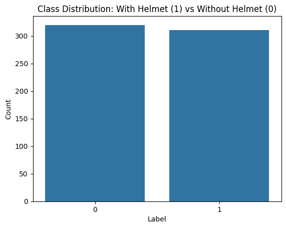

```python
#EDA
#Univariate and Bivariate analysis
# Plot the class distribution with Seaborn countplot.
sns.countplot(x=y_df['Label'])
plt.title("Class Distribution: With Helmet (1) vs Without Helmet (0)")
plt.xlabel("Label")
plt.ylabel("Count")
plt.show()
```

Observations:

1. Data distribution is almost similar with no helmet and helmet (as per data 320 are No Helmet and 311 are helmet)

# Plot random images from each of the classes and print their corresponding labels

```python
# Convert to NumPy array if not already
X = np.array(X)
y = np.array(y)

# Find indices for each class
helmet_indices = np.where(y == 1)[0]
no_helmet_indices = np.where(y == 0)[0]
```

```python
# Pick 5 random indices from each
helmet_samples = random.sample(list(helmet_indices), 5)
no_helmet_samples = random.sample(list(no_helmet_indices), 5)
```

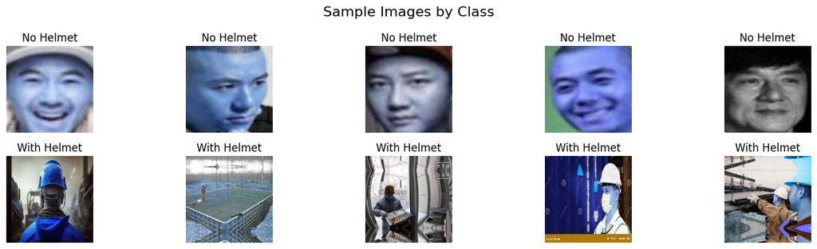

```python
# Plot images without helmet
plt.figure(figsize=(15, 4))

for i, idx in enumerate(no_helmet_samples):
    plt.subplot(2, 5, i+1)
    plt.imshow(X[idx].squeeze(), cmap='gray' if X.shape[-1] == 1 else None) # Ensures any grayscale images are shown correctly
    plt.title("No Helmet")
    plt.axis('off')

# Plot images with helmet
for i, idx in enumerate(helmet_samples):
    plt.subplot(2, 5, i+6)
    plt.imshow(X[idx].squeeze(), cmap='gray' if X.shape[-1] == 1 else None)
    plt.title("With Helmet")
    plt.axis('off')

plt.suptitle("Sample Images by Class", fontsize=16)
plt.tight_layout()
plt.show()
```

```python
#Data Preprocessing
# Convert RGB images to Grayscale
X_gray = np.array([cv2.cvtColor(img, cv2.COLOR_RGB2GRAY) for img in X])

# Reshape to match CNN input (samples, height, width, channels)
X_gray = X_gray.reshape(X_gray.shape[0], X_gray.shape[1], X_gray.shape[2], 1)

# Confirm shape
print(f"X_gray shape: {X_gray.shape}")
```

```
X_gray shape: (631, 200, 200, 1)
```

All images are converted to grey scale image with 1 channel and 200x200 pixels

```python
#Split the data set for train/validation/test

# 70% train, 30% temp (val+test)
X_train, X_temp, y_train, y_temp = train_test_split(
    X_gray, y, test_size=0.3, random_state=42, stratify=y
)

# 50% of the temp set goes to val, 50% to test
X_val, X_test, y_val, y_test = train_test_split(
    X_temp, y_temp, test_size=0.5, random_state=42, stratify=y_temp
)
```

```python
print(f"Train set: {X_train.shape[0]}")
print(f"Validation set: {X_val.shape[0]}")
print(f"Test set: {X_test.shape[0]}")
```

```
Train set: 441
Validation set: 95
Test set: 95
```

```python
# Data Normalization

# Since pixel values are currently in the range [0, 255] (as is typical for images), we’ll scale them to the range [0.0, 1.0] by dividing by 255
# Normalize grayscale pixel values to [0.0, 1.0]
X_train = X_train / 255.0
X_val = X_val / 255.0
X_test = X_test / 255.0

print(f"Train min: {X_train.min()}, max: {X_train.max()}")
print(f"Val min: {X_val.min()}, max: {X_val.max()}")
print(f"Test min: {X_test.min()}, max: {X_test.max()}")
```

```
Train min: 0.0, max: 1.0
Val min: 0.0, max: 1.0
Test min: 0.0, max: 1.0
```

All the values are now in range of 0 to 1. Now we can feed this data to CNNs

```python
def model_performance_classification(model, predictors, target):
    """
    Function to compute different metrics to check classification model performance

    model: classifier
    predictors: independent variables
    target: dependent variable
    """

    # checking which probabilities are greater than threshold
    pred = model.predict(predictors).reshape(-1)>0.5

    target = target.reshape(-1)


    acc = accuracy_score(target, pred)  # to compute Accuracy
    recall = recall_score(target, pred, average='weighted')  # to compute Recall
    precision = precision_score(target, pred, average='weighted')  # to compute Precision
    f1 = f1_score(target, pred, average='weighted')  # to compute F1-score

    # creating a dataframe of metrics
    df_perf = pd.DataFrame({"Accuracy": acc, "Recall": recall, "Precision": precision, "F1 Score": f1,},index=[0],)

    return df_perf
```

```python
def plot_confusion_matrix(model,predictors,target,ml=False):
    """
    Function to plot the confusion matrix

    model: classifier
    predictors: independent variables
    target: dependent variable
    ml: To specify if the model used is an sklearn ML model or not (True means ML model)
    """

    # checking which probabilities are greater than threshold
    pred = model.predict(predictors).reshape(-1)>0.5

    target = target.reshape(-1)

    # Plotting the Confusion Matrix using confusion matrix() function which is also predefined tensorflow module
    confusion_matrix = tf.math.confusion_matrix(target,pred)
    f, ax = plt.subplots(figsize=(10, 8))
    sns.heatmap(
        confusion_matrix,
        annot=True,
        linewidths=.4,
        fmt="d",
        square=True,
        ax=ax
    )
    plt.show()
```

```python
# Model 1: Simple Convolutional Neural Network (CNN)

# Define CNN architecture

cnn_model_1 = Sequential([Conv2D(32, (3,3), activation = 'relu', input_shape = X_train.shape[1:]),
                          MaxPooling2D(pool_size = (2,2)),

                          Conv2D(64, (3,3), activation = 'relu'),
                          MaxPooling2D (pool_size = (2,2)),

                          Flatten(),
                          Dense(128, activation = 'relu'),
                          Dropout(0.5),
                          Dense(1, activation = 'sigmoid')
                          ])

#Compile model

cnn_model_1.compile(optimizer ='adam', loss='binary_crossentropy', metrics=['accuracy'] )

#Model summary
cnn_model_1.summary()
```

```
Model: "sequential_4"
```

```
┏━━━━━━━━━━━━━━━━━━━━━━━━━━━━━━━━━┳━━━━━━━━━━━━━━━━━━━━━━━━┳━━━━━━━━━━━━━━━┓
┃ Layer (type)                    ┃ Output Shape           ┃       Param # ┃
┡━━━━━━━━━━━━━━━━━━━━━━━━━━━━━━━━━╇━━━━━━━━━━━━━━━━━━━━━━━━╇━━━━━━━━━━━━━━━┩
│ conv2d_8 (Conv2D)               │ (None, 198, 198, 32)   │           320 │
├─────────────────────────────────┼────────────────────────┼───────────────┤
│ max_pooling2d_8 (MaxPooling2D)  │ (None, 99, 99, 32)     │             0 │
├─────────────────────────────────┼────────────────────────┼───────────────┤
│ conv2d_9 (Conv2D)               │ (None, 97, 97, 64)     │        18,496 │
├─────────────────────────────────┼────────────────────────┼───────────────┤
│ max_pooling2d_9 (MaxPooling2D)  │ (None, 48, 48, 64)     │             0 │
├─────────────────────────────────┼────────────────────────┼───────────────┤
│ flatten_14 (Flatten)            │ (None, 147456)         │             0 │
├─────────────────────────────────┼────────────────────────┼───────────────┤
│ dense_34 (Dense)                │ (None, 128)            │    18,874,496 │
├─────────────────────────────────┼────────────────────────┼───────────────┤
│ dropout_20 (Dropout)            │ (None, 128)            │             0 │
├─────────────────────────────────┼────────────────────────┼───────────────┤
│ dense_35 (Dense)                │ (None, 1)              │           129 │
└─────────────────────────────────┴────────────────────────┴───────────────┘
```

```
 Total params: 18,893,441 (72.07 MB)
```

```
 Trainable params: 18,893,441 (72.07 MB)
```

```
 Non-trainable params: 0 (0.00 B)
```

```python
#Train model

train_cnn_model_1 = cnn_model_1.fit(X_train, y_train, validation_data = (X_val, y_val), batch_size = 32, epochs = 10, verbose = 2)
```

```
14/14 - 5s - 370ms/step - accuracy: 0.7302 - loss: 1.4837 - val_accuracy: 0.9263 - val_loss: 0.2863
14/14 - 0s - 15ms/step - accuracy: 0.9524 - loss: 0.1778 - val_accuracy: 0.9684 - val_loss: 0.0892
14/14 - 0s - 15ms/step - accuracy: 0.9728 - loss: 0.0870 - val_accuracy: 0.9895 - val_loss: 0.0768
14/14 - 0s - 15ms/step - accuracy: 0.9909 - loss: 0.0444 - val_accuracy: 0.9789 - val_loss: 0.0628
14/14 - 0s - 15ms/step - accuracy: 0.9955 - loss: 0.0169 - val_accuracy: 0.9684 - val_loss: 0.0902
14/14 - 0s - 15ms/step - accuracy: 0.9955 - loss: 0.0154 - val_accuracy: 0.9789 - val_loss: 0.0659
14/14 - 0s - 15ms/step - accuracy: 0.9977 - loss: 0.0092 - val_accuracy: 0.9895 - val_loss: 0.0793
14/14 - 0s - 15ms/step - accuracy: 1.0000 - loss: 0.0038 - val_accuracy: 0.9789 - val_loss: 0.0739
14/14 - 0s - 15ms/step - accuracy: 1.0000 - loss: 0.0023 - val_accuracy: 0.9789 - val_loss: 0.0782
14/14 - 0s - 15ms/step - accuracy: 1.0000 - loss: 0.0023 - val_accuracy: 0.9789 - val_loss: 0.0828
```

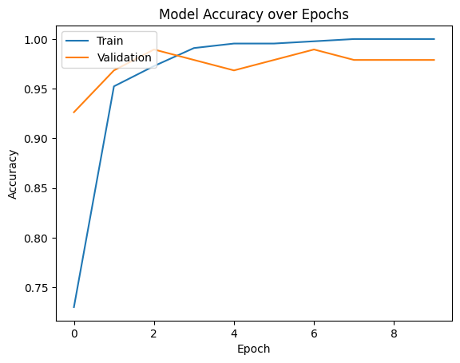

```python
plt.plot(train_cnn_model_1.history['accuracy'])
plt.plot(train_cnn_model_1.history['val_accuracy'])
plt.title('Model Accuracy over Epochs')
plt.ylabel('Accuracy')
plt.xlabel('Epoch')
plt.legend(['Train', 'Validation'], loc='upper left')
plt.show()
```

Observations:

1. Accuracy of validation data looks stable at around 97%
2. Observed constant accuracy in training data around epoch 4 at 1. Could be due to overfitting of training data.

```
Training performane metrics:
14/14 ━━━━━━━━━━━━━━━━━━━━ 1s 26ms/step
   Accuracy  Recall  Precision  F1 Score
0       1.0     1.0        1.0       1.0
14/14 ━━━━━━━━━━━━━━━━━━━━ 0s 4ms/step
```

```
Validation performane metrics:
3/3 ━━━━━━━━━━━━━━━━━━━━ 0s 125ms/step
   Accuracy    Recall  Precision  F1 Score
0  0.978947  0.978947   0.978947  0.978947
3/3 ━━━━━━━━━━━━━━━━━━━━ 0s 11ms/step
```

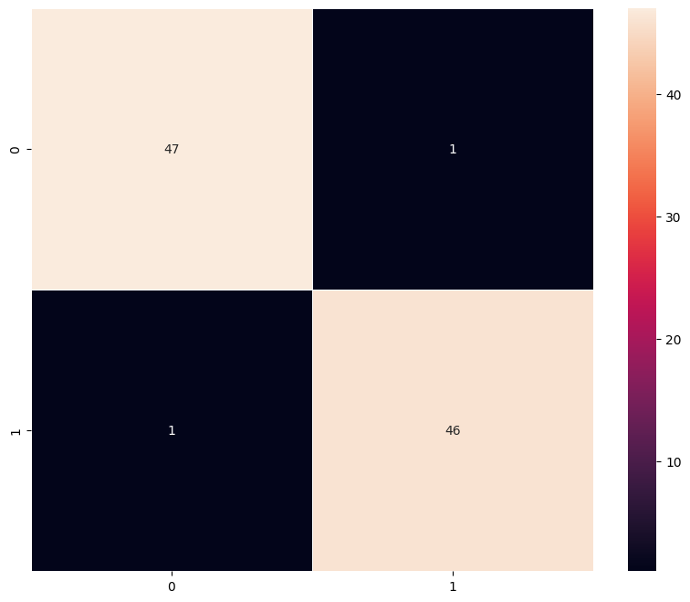

```python
#Evaluate train and validation sets

print("Training performane metrics:")
cnn_model_1_train_perf = model_performance_classification(cnn_model_1, X_train, y_train)
print(cnn_model_1_train_perf)
plot_confusion_matrix(cnn_model_1, X_train, y_train)

print("Validation performane metrics:")
cnn_model_1_val_perf = model_performance_classification(cnn_model_1, X_val, y_val)
print(cnn_model_1_val_perf)
plot_confusion_matrix(cnn_model_1, X_val, y_val)
```

Observations:

1. Training data shows perfect accuracy and scores shows 100% on all performance metrics.
2. Accuracy is around 97% on validation set may be because of small image set out of 631 images.

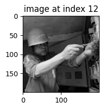

```
1/1 ━━━━━━━━━━━━━━━━━━━━ 0s 249ms/step
Predicted label: 1
Actual label: 1
```

```python
#Visualizing the predictions

index = 12
plt.figure(figsize=(2,2))
plt.imshow(X_val[index].reshape(X_val.shape[1], X_val.shape[2]), cmap = 'gray')
plt.title(f"image at index {index}")
plt.show()

prediction = cnn_model_1.predict(X_val[index].reshape(1, X_val.shape[1], X_val.shape[2], 1))
predicted_label = 1 if prediction[0][0] > 0.5 else 0

print(f"Predicted label: {predicted_label}")
print(f"Actual label: {y_val[index]}")
```

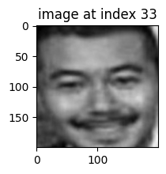

```
1/1 ━━━━━━━━━━━━━━━━━━━━ 0s 33ms/step
Predicted label: 0
Actual label: 0
```

```python
index = 33
plt.figure(figsize=(2,2))
plt.imshow(X_val[index].reshape(X_val.shape[1], X_val.shape[2]), cmap = 'gray')
plt.title(f"image at index {index}")
plt.show()

prediction = cnn_model_1.predict(X_val[index].reshape(1, X_val.shape[1], X_val.shape[2], 1))
predicted_label = 1 if prediction[0][0] > 0.5 else 0

print(f"Predicted label: {predicted_label}")
print(f"Actual label: {y_val[index]}")
```

Observations:

1. Looks like model 1 has predicted correctly for images at index 12 and 33

```python
#MODEL 2 VGG 16(Base)

# VGG 16 expects 3 channel images, so we can convert images back to 3 channel

# Convert greyscale to rgb images

X_train_vgg = np.repeat(X_train, 3, axis=-1)
X_val_vgg = np.repeat(X_val, 3, axis=-1)
X_test_vgg = np.repeat(X_test, 3, axis=-1)
```

```python
#Load VGG without top classifier

vgg_base = VGG16(weights='imagenet', include_top=False, input_shape=X_train_vgg.shape[1:])

#Freeze layers
for layer in vgg_base.layers:
  layer.trainable = False

#Unfreeze last 4 layers
for layer in vgg_base.layers[-4:]:
  layer.trainable = True
```

```python
#Add custom head
x=vgg_base.output
x = Flatten()(x)
x=Dense(128, activation='relu')(x)
x=Dropout(0.8)(x)
output = Dense(1, activation='sigmoid')(x)

#Final model
cnn_model_2 = Model(inputs = vgg_base.input, outputs = output)
```

```python
#Let's compile the model

cnn_model_2.compile(optimizer=Adam(learning_rate=0.000001), loss='binary_crossentropy', metrics=['accuracy'])

cnn_model_2.summary()
```

```
Model: "functional_16"
```

```
┏━━━━━━━━━━━━━━━━━━━━━━━━━━━━━━━━━┳━━━━━━━━━━━━━━━━━━━━━━━━┳━━━━━━━━━━━━━━━┓
┃ Layer (type)                    ┃ Output Shape           ┃       Param # ┃
┡━━━━━━━━━━━━━━━━━━━━━━━━━━━━━━━━━╇━━━━━━━━━━━━━━━━━━━━━━━━╇━━━━━━━━━━━━━━━┩
│ input_layer_15 (InputLayer)     │ (None, 200, 200, 3)    │             0 │
├─────────────────────────────────┼────────────────────────┼───────────────┤
│ block1_conv1 (Conv2D)           │ (None, 200, 200, 64)   │         1,792 │
├─────────────────────────────────┼────────────────────────┼───────────────┤
│ block1_conv2 (Conv2D)           │ (None, 200, 200, 64)   │        36,928 │
├─────────────────────────────────┼────────────────────────┼───────────────┤
│ block1_pool (MaxPooling2D)      │ (None, 100, 100, 64)   │             0 │
├─────────────────────────────────┼────────────────────────┼───────────────┤
│ block2_conv1 (Conv2D)           │ (None, 100, 100, 128)  │        73,856 │
├─────────────────────────────────┼────────────────────────┼───────────────┤
│ block2_conv2 (Conv2D)           │ (None, 100, 100, 128)  │       147,584 │
├─────────────────────────────────┼────────────────────────┼───────────────┤
│ block2_pool (MaxPooling2D)      │ (None, 50, 50, 128)    │             0 │
├─────────────────────────────────┼────────────────────────┼───────────────┤
│ block3_conv1 (Conv2D)           │ (None, 50, 50, 256)    │       295,168 │
├─────────────────────────────────┼────────────────────────┼───────────────┤
│ block3_conv2 (Conv2D)           │ (None, 50, 50, 256)    │       590,080 │
├─────────────────────────────────┼────────────────────────┼───────────────┤
│ block3_conv3 (Conv2D)           │ (None, 50, 50, 256)    │       590,080 │
├─────────────────────────────────┼────────────────────────┼───────────────┤
│ block3_pool (MaxPooling2D)      │ (None, 25, 25, 256)    │             0 │
├─────────────────────────────────┼────────────────────────┼───────────────┤
│ block4_conv1 (Conv2D)           │ (None, 25, 25, 512)    │     1,180,160 │
├─────────────────────────────────┼────────────────────────┼───────────────┤
│ block4_conv2 (Conv2D)           │ (None, 25, 25, 512)    │     2,359,808 │
├─────────────────────────────────┼────────────────────────┼───────────────┤
│ block4_conv3 (Conv2D)           │ (None, 25, 25, 512)    │     2,359,808 │
├─────────────────────────────────┼────────────────────────┼───────────────┤
│ block4_pool (MaxPooling2D)      │ (None, 12, 12, 512)    │             0 │
├─────────────────────────────────┼────────────────────────┼───────────────┤
│ block5_conv1 (Conv2D)           │ (None, 12, 12, 512)    │     2,359,808 │
├─────────────────────────────────┼────────────────────────┼───────────────┤
│ block5_conv2 (Conv2D)           │ (None, 12, 12, 512)    │     2,359,808 │
├─────────────────────────────────┼────────────────────────┼───────────────┤
│ block5_conv3 (Conv2D)           │ (None, 12, 12, 512)    │     2,359,808 │
├─────────────────────────────────┼────────────────────────┼───────────────┤
│ block5_pool (MaxPooling2D)      │ (None, 6, 6, 512)      │             0 │
├─────────────────────────────────┼────────────────────────┼───────────────┤
│ flatten_15 (Flatten)            │ (None, 18432)          │             0 │
├─────────────────────────────────┼────────────────────────┼───────────────┤
│ dense_36 (Dense)                │ (None, 128)            │     2,359,424 │
├─────────────────────────────────┼────────────────────────┼───────────────┤
│ dropout_21 (Dropout)            │ (None, 128)            │             0 │
├─────────────────────────────────┼────────────────────────┼───────────────┤
│ dense_37 (Dense)                │ (None, 1)              │           129 │
└─────────────────────────────────┴────────────────────────┴───────────────┘
```

```
 Total params: 17,074,241 (65.13 MB)
```

```
 Trainable params: 9,438,977 (36.01 MB)
```

```
 Non-trainable params: 7,635,264 (29.13 MB)
```

```python
#Train the model

cnn_model_2_train = cnn_model_2.fit(X_train_vgg, y_train, validation_data = (X_train_vgg, y_train), batch_size = 32, epochs =10, verbose=2)
```

```
14/14 - 8s - 544ms/step - accuracy: 0.5193 - loss: 0.8675 - val_accuracy: 0.4921 - val_loss: 0.6827
14/14 - 1s - 39ms/step - accuracy: 0.4943 - loss: 0.8529 - val_accuracy: 0.5828 - val_loss: 0.6340
14/14 - 1s - 39ms/step - accuracy: 0.5692 - loss: 0.7801 - val_accuracy: 0.7324 - val_loss: 0.5893
14/14 - 1s - 38ms/step - accuracy: 0.5692 - loss: 0.7797 - val_accuracy: 0.8639 - val_loss: 0.5477
14/14 - 1s - 39ms/step - accuracy: 0.6281 - loss: 0.6870 - val_accuracy: 0.9592 - val_loss: 0.5106
14/14 - 1s - 39ms/step - accuracy: 0.6735 - loss: 0.6240 - val_accuracy: 0.9887 - val_loss: 0.4772
14/14 - 1s - 38ms/step - accuracy: 0.6735 - loss: 0.6096 - val_accuracy: 0.9932 - val_loss: 0.4453
14/14 - 1s - 39ms/step - accuracy: 0.6667 - loss: 0.6114 - val_accuracy: 0.9955 - val_loss: 0.4154
14/14 - 1s - 39ms/step - accuracy: 0.6916 - loss: 0.5909 - val_accuracy: 0.9977 - val_loss: 0.3853
14/14 - 1s - 38ms/step - accuracy: 0.7415 - loss: 0.5102 - val_accuracy: 1.0000 - val_loss: 0.3570
```

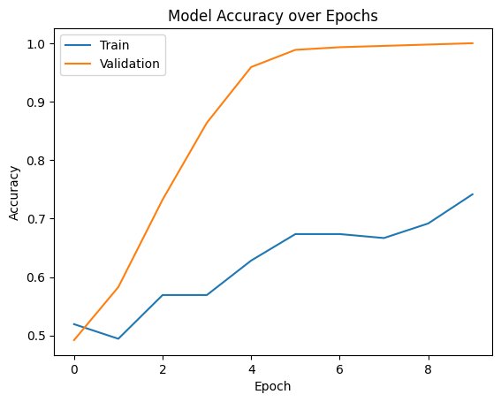

```python
plt.plot(cnn_model_2_train.history['accuracy'])
plt.plot(cnn_model_2_train.history['val_accuracy'])
plt.title('Model Accuracy over Epochs')
plt.ylabel('Accuracy')
plt.xlabel('Epoch')
plt.legend(['Train', 'Validation'], loc='upper left')
plt.show()
```

Observations:

```
Train performance metrics:
14/14 ━━━━━━━━━━━━━━━━━━━━ 1s 62ms/step
```

|  | Accuracy | Recall | Precision | F1 Score |
| --- | --- | --- | --- | --- |
| 0 | 1.0 | 1.0 | 1.0 | 1.0 |

```
14/14 ━━━━━━━━━━━━━━━━━━━━ 0s 16ms/step
```

```
Validation performance metrics:
3/3 ━━━━━━━━━━━━━━━━━━━━ 1s 251ms/step
```

|  | Accuracy | Recall | Precision | F1 Score |
| --- | --- | --- | --- | --- |
| 0 | 0.978947 | 0.978947 | 0.979807 | 0.978943 |

```
3/3 ━━━━━━━━━━━━━━━━━━━━ 0s 23ms/step
```

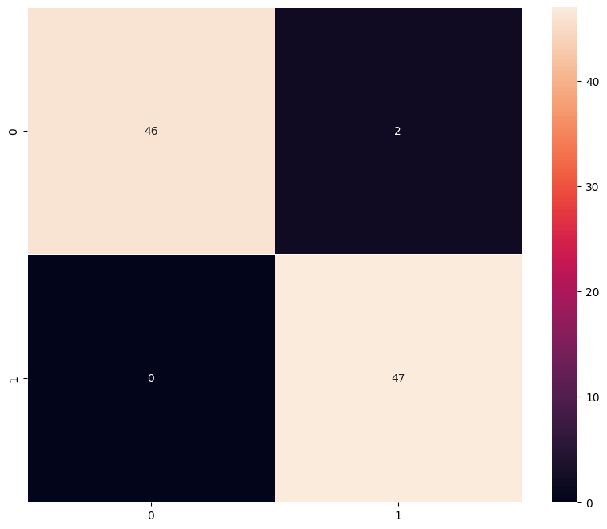

```python
# Evaluate on Train Set
print("Train performance metrics:")
cnn_model_2_train_perf = model_performance_classification(cnn_model_2, X_train_vgg, y_train)
display(cnn_model_2_train_perf)

plot_confusion_matrix(cnn_model_2, X_train_vgg, y_train)

# Evaluate on Validation Set
print("Validation performance metrics:")
cnn_model_2_val_perf = model_performance_classification(cnn_model_2, X_val_vgg, y_val)
display(cnn_model_2_val_perf)

plot_confusion_matrix(cnn_model_2, X_val_vgg, y_val)
```

```python
print("Train:", np.bincount(y_train))
print("Val:", np.bincount(y_val))
print("Test:", np.bincount(y_test))
```

```
Train: [224 217]
Val: [48 47]
Test: [48 47]
```

```python
#Vizualizing the predictions

# For index 12
index = 12
plt.figure(figsize=(2, 2))
plt.imshow(X_val[index].reshape(X_val.shape[1], X_val.shape[2]), cmap='gray')  # grayscale view
plt.title(f"Image at index {index}")
plt.show()

# Predict using the RGB-converted version
prediction = cnn_model_2.predict(X_val_vgg[index].reshape(1, X_val.shape[1], X_val.shape[2], 3))
predicted_label = 1 if prediction[0][0] > 0.5 else 0
print('Predicted Label:', predicted_label)
print('Actual Label:', y_val[index])

# For index 33
index = 33
plt.figure(figsize=(2, 2))
plt.imshow(X_val[index].reshape(X_val.shape[1], X_val.shape[2]), cmap='gray')  # grayscale view
plt.title(f"Image at index {index}")
plt.show()

prediction = cnn_model_2.predict(X_val_vgg[index].reshape(1, X_val.shape[1], X_val.shape[2], 3))
predicted_label = 1 if prediction[0][0] > 0.5 else 0
print('Predicted Label:', predicted_label)
print('Actual Label:', y_val[index])
```

```
1/1 ━━━━━━━━━━━━━━━━━━━━ 1s 529ms/step
Predicted Label: 1
Actual Label: 1
```

```
1/1 ━━━━━━━━━━━━━━━━━━━━ 0s 36ms/step
Predicted Label: 0
Actual Label: 0
```

Observations: From the above prediction, we can see that the model predicted both images correctly

```python
#Model 3: (VGG-16 (Base + FFNN))
# instead of simple head, we can try this model with deeper classification heads

#Convert greyscale to RGB
X_train_vgg = np.repeat(X_train, 3, axis=-1)
X_val_vgg = np.repeat(X_val, 3, axis=-1)
X_test_vgg = np.repeat(X_test, 3, axis=-1)
```

```python
# Load base VGG16 model without top layer
vgg_base = VGG16(weights='imagenet', include_top=False, input_shape=X_train_vgg.shape[1:])

# Freeze all layers first
for layer in vgg_base.layers:
    layer.trainable = False
```

```python
#Add deeper FFNN head
x = vgg_base.output
x = Flatten()(x)
x = Dense(256, activation='relu')(x)
x = Dropout(0.7)(x)
x = Dense(128, activation='relu')(x)
x = Dropout(0.8)(x)
output = Dense(1, activation='sigmoid')(x)
```

```python
#Define model
cnn_model_3 = Model(inputs=vgg_base.input, outputs=output)

#Compile model
cnn_model_3.compile(optimizer=Adam(learning_rate=0.00001), loss='binary_crossentropy', metrics=['accuracy'])

cnn_model_3.summary()
```

```
Model: "functional_17"
```

```
┏━━━━━━━━━━━━━━━━━━━━━━━━━━━━━━━━━┳━━━━━━━━━━━━━━━━━━━━━━━━┳━━━━━━━━━━━━━━━┓
┃ Layer (type)                    ┃ Output Shape           ┃       Param # ┃
┡━━━━━━━━━━━━━━━━━━━━━━━━━━━━━━━━━╇━━━━━━━━━━━━━━━━━━━━━━━━╇━━━━━━━━━━━━━━━┩
│ input_layer_16 (InputLayer)     │ (None, 200, 200, 3)    │             0 │
├─────────────────────────────────┼────────────────────────┼───────────────┤
│ block1_conv1 (Conv2D)           │ (None, 200, 200, 64)   │         1,792 │
├─────────────────────────────────┼────────────────────────┼───────────────┤
│ block1_conv2 (Conv2D)           │ (None, 200, 200, 64)   │        36,928 │
├─────────────────────────────────┼────────────────────────┼───────────────┤
│ block1_pool (MaxPooling2D)      │ (None, 100, 100, 64)   │             0 │
├─────────────────────────────────┼────────────────────────┼───────────────┤
│ block2_conv1 (Conv2D)           │ (None, 100, 100, 128)  │        73,856 │
├─────────────────────────────────┼────────────────────────┼───────────────┤
│ block2_conv2 (Conv2D)           │ (None, 100, 100, 128)  │       147,584 │
├─────────────────────────────────┼────────────────────────┼───────────────┤
│ block2_pool (MaxPooling2D)      │ (None, 50, 50, 128)    │             0 │
├─────────────────────────────────┼────────────────────────┼───────────────┤
│ block3_conv1 (Conv2D)           │ (None, 50, 50, 256)    │       295,168 │
├─────────────────────────────────┼────────────────────────┼───────────────┤
│ block3_conv2 (Conv2D)           │ (None, 50, 50, 256)    │       590,080 │
├─────────────────────────────────┼────────────────────────┼───────────────┤
│ block3_conv3 (Conv2D)           │ (None, 50, 50, 256)    │       590,080 │
├─────────────────────────────────┼────────────────────────┼───────────────┤
│ block3_pool (MaxPooling2D)      │ (None, 25, 25, 256)    │             0 │
├─────────────────────────────────┼────────────────────────┼───────────────┤
│ block4_conv1 (Conv2D)           │ (None, 25, 25, 512)    │     1,180,160 │
├─────────────────────────────────┼────────────────────────┼───────────────┤
│ block4_conv2 (Conv2D)           │ (None, 25, 25, 512)    │     2,359,808 │
├─────────────────────────────────┼────────────────────────┼───────────────┤
│ block4_conv3 (Conv2D)           │ (None, 25, 25, 512)    │     2,359,808 │
├─────────────────────────────────┼────────────────────────┼───────────────┤
│ block4_pool (MaxPooling2D)      │ (None, 12, 12, 512)    │             0 │
├─────────────────────────────────┼────────────────────────┼───────────────┤
│ block5_conv1 (Conv2D)           │ (None, 12, 12, 512)    │     2,359,808 │
├─────────────────────────────────┼────────────────────────┼───────────────┤
│ block5_conv2 (Conv2D)           │ (None, 12, 12, 512)    │     2,359,808 │
├─────────────────────────────────┼────────────────────────┼───────────────┤
│ block5_conv3 (Conv2D)           │ (None, 12, 12, 512)    │     2,359,808 │
├─────────────────────────────────┼────────────────────────┼───────────────┤
│ block5_pool (MaxPooling2D)      │ (None, 6, 6, 512)      │             0 │
├─────────────────────────────────┼────────────────────────┼───────────────┤
│ flatten_16 (Flatten)            │ (None, 18432)          │             0 │
├─────────────────────────────────┼────────────────────────┼───────────────┤
│ dense_38 (Dense)                │ (None, 256)            │     4,718,848 │
├─────────────────────────────────┼────────────────────────┼───────────────┤
│ dropout_22 (Dropout)            │ (None, 256)            │             0 │
├─────────────────────────────────┼────────────────────────┼───────────────┤
│ dense_39 (Dense)                │ (None, 128)            │        32,896 │
├─────────────────────────────────┼────────────────────────┼───────────────┤
│ dropout_23 (Dropout)            │ (None, 128)            │             0 │
├─────────────────────────────────┼────────────────────────┼───────────────┤
│ dense_40 (Dense)                │ (None, 1)              │           129 │
└─────────────────────────────────┴────────────────────────┴───────────────┘
```

```
 Total params: 19,466,561 (74.26 MB)
```

```
 Trainable params: 4,751,873 (18.13 MB)
```

```
 Non-trainable params: 14,714,688 (56.13 MB)
```

```python
#Train the model
cnn_model_3_train = cnn_model_3.fit(X_train_vgg, y_train, validation_data=(X_val_vgg, y_val), batch_size=32, epochs=10, verbose=2)
```

```
14/14 - 7s - 506ms/step - accuracy: 0.5238 - loss: 1.1254 - val_accuracy: 0.8421 - val_loss: 0.5863
14/14 - 0s - 26ms/step - accuracy: 0.5828 - loss: 1.0005 - val_accuracy: 0.9053 - val_loss: 0.5169
14/14 - 0s - 24ms/step - accuracy: 0.5850 - loss: 0.8331 - val_accuracy: 0.8842 - val_loss: 0.4708
14/14 - 0s - 24ms/step - accuracy: 0.5805 - loss: 0.7852 - val_accuracy: 0.9158 - val_loss: 0.4353
14/14 - 0s - 24ms/step - accuracy: 0.6372 - loss: 0.7246 - val_accuracy: 0.9474 - val_loss: 0.3967
14/14 - 0s - 24ms/step - accuracy: 0.6712 - loss: 0.6403 - val_accuracy: 0.9789 - val_loss: 0.3614
14/14 - 0s - 24ms/step - accuracy: 0.7370 - loss: 0.5555 - val_accuracy: 0.9789 - val_loss: 0.3361
14/14 - 0s - 24ms/step - accuracy: 0.7324 - loss: 0.5369 - val_accuracy: 0.9789 - val_loss: 0.3153
14/14 - 0s - 25ms/step - accuracy: 0.7642 - loss: 0.4901 - val_accuracy: 0.9895 - val_loss: 0.2895
14/14 - 0s - 24ms/step - accuracy: 0.7982 - loss: 0.4480 - val_accuracy: 0.9895 - val_loss: 0.2679
```

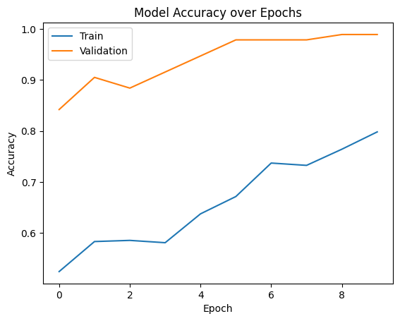

```python
plt.plot(cnn_model_3_train.history['accuracy'])
plt.plot(cnn_model_3_train.history['val_accuracy'])
plt.title('Model Accuracy over Epochs')
plt.ylabel('Accuracy')
plt.xlabel('Epoch')
plt.legend(['Train', 'Validation'], loc='upper left')
plt.show()
```

Observations:

```
Train performance metrics:
14/14 ━━━━━━━━━━━━━━━━━━━━ 2s 80ms/step
```

|  | Accuracy | Recall | Precision | F1 Score |
| --- | --- | --- | --- | --- |
| 0 | 1.0 | 1.0 | 1.0 | 1.0 |

```
14/14 ━━━━━━━━━━━━━━━━━━━━ 0s 15ms/step
```

```
Validation performance metrics:
3/3 ━━━━━━━━━━━━━━━━━━━━ 1s 358ms/step
```

|  | Accuracy | Recall | Precision | F1 Score |
| --- | --- | --- | --- | --- |
| 0 | 0.989474 | 0.989474 | 0.989689 | 0.989471 |

```
3/3 ━━━━━━━━━━━━━━━━━━━━ 0s 23ms/step
```

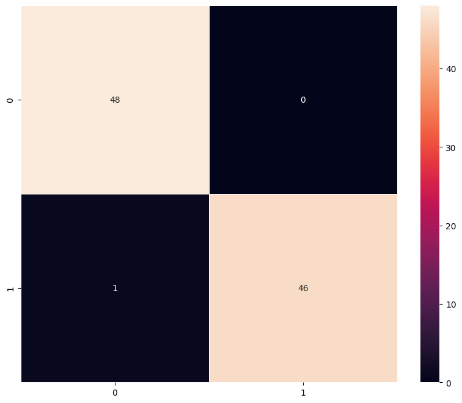

```python
print("Train performance metrics:")
cnn_model_3_train_perf = model_performance_classification(cnn_model_3, X_train_vgg, y_train)
display(cnn_model_3_train_perf)

plot_confusion_matrix(cnn_model_3, X_train_vgg, y_train)

print("Validation performance metrics:")
cnn_model_3_val_perf = model_performance_classification(cnn_model_3, X_val_vgg, y_val)
display(cnn_model_3_val_perf)

plot_confusion_matrix(cnn_model_3, X_val_vgg, y_val)
```

```python
print("Train:", np.bincount(y_train))
print("Val:", np.bincount(y_val))
print("Test:", np.bincount(y_test))
```

```
Train: [224 217]
Val: [48 47]
Test: [48 47]
```

```python
#Vizualizing the predictions

# For index 12
index = 12
plt.figure(figsize=(2, 2))
plt.imshow(X_val[index].reshape(X_val.shape[1], X_val.shape[2]), cmap='gray')  # grayscale view
plt.title(f"Image at index {index}")
plt.show()

# Predict using the RGB-converted version
prediction = cnn_model_3.predict(X_val_vgg[index].reshape(1, X_val.shape[1], X_val.shape[2], 3))
predicted_label = 1 if prediction[0][0] > 0.5 else 0
print('Predicted Label:', predicted_label)
print('Actual Label:', y_val[index])

# For index 33
index = 33
plt.figure(figsize=(2, 2))
plt.imshow(X_val[index].reshape(X_val.shape[1], X_val.shape[2]), cmap='gray')  # grayscale view
plt.title(f"Image at index {index}")
plt.show()

prediction = cnn_model_3.predict(X_val_vgg[index].reshape(1, X_val.shape[1], X_val.shape[2], 3))
predicted_label = 1 if prediction[0][0] > 0.5 else 0
print('Predicted Label:', predicted_label)
print('Actual Label:', y_val[index])
```

```
1/1 ━━━━━━━━━━━━━━━━━━━━ 1s 557ms/step
Predicted Label: 1
Actual Label: 1
```

```
1/1 ━━━━━━━━━━━━━━━━━━━━ 0s 35ms/step
Predicted Label: 0
Actual Label: 0
```

Observations:

1. From above prediction we can say model has predicted the images correctly.

```python
# Model 4: (VGG-16 (Base + FFNN + Data Augmentation)

#In real world scenarios getting large test data images might be challenging to train CNNs
# To overcome this problem we can use data augmentation

#convert greyscale to RGB
X_train_vgg = np.repeat(X_train, 3, axis=-1)
X_val_vgg = np.repeat(X_val, 3, axis=-1)
X_test_vgg = np.repeat(X_test, 3, axis=-1)
```

```python
#Data Augmentation applied to only training data

train_datagen= ImageDataGenerator(rotation_range=15,
    width_shift_range=0.1,
    height_shift_range=0.1,
    zoom_range=0.1,
    horizontal_flip=True,
    fill_mode='nearest')

# Validation/Test generators (no augmentation)
val_datagen = ImageDataGenerator()

# Flow from arrays
train_generator = train_datagen.flow(X_train_vgg, y_train, batch_size=32)
val_generator = val_datagen.flow(X_val_vgg, y_val, batch_size=32)
```

```python
# Load VGG16 without the top classifier (reuse from cnn_model_3)

vgg_base = VGG16(weights='imagenet', include_top=False, input_shape=X_train_vgg.shape[1:])
for layer in vgg_base.layers:
    layer.trainable = False

x = vgg_base.output
x = Flatten()(x)
x = Dense(256, activation='relu')(x)
x = Dropout(0.7)(x)
x = Dense(128, activation='relu')(x)
x = Dropout(0.8)(x)
output = Dense(1, activation='sigmoid')(x)

cnn_model_4 = Model(inputs=vgg_base.input, outputs=output)
```

```python
#Compile model
cnn_model_4.compile(
    optimizer=Adam(learning_rate=0.000001),  # small LR is safer with pre-trained weights
    loss='binary_crossentropy',
    metrics=['accuracy']
)

cnn_model_4.summary()
```

```
Model: "functional_18"
```

```
┏━━━━━━━━━━━━━━━━━━━━━━━━━━━━━━━━━┳━━━━━━━━━━━━━━━━━━━━━━━━┳━━━━━━━━━━━━━━━┓
┃ Layer (type)                    ┃ Output Shape           ┃       Param # ┃
┡━━━━━━━━━━━━━━━━━━━━━━━━━━━━━━━━━╇━━━━━━━━━━━━━━━━━━━━━━━━╇━━━━━━━━━━━━━━━┩
│ input_layer_17 (InputLayer)     │ (None, 200, 200, 3)    │             0 │
├─────────────────────────────────┼────────────────────────┼───────────────┤
│ block1_conv1 (Conv2D)           │ (None, 200, 200, 64)   │         1,792 │
├─────────────────────────────────┼────────────────────────┼───────────────┤
│ block1_conv2 (Conv2D)           │ (None, 200, 200, 64)   │        36,928 │
├─────────────────────────────────┼────────────────────────┼───────────────┤
│ block1_pool (MaxPooling2D)      │ (None, 100, 100, 64)   │             0 │
├─────────────────────────────────┼────────────────────────┼───────────────┤
│ block2_conv1 (Conv2D)           │ (None, 100, 100, 128)  │        73,856 │
├─────────────────────────────────┼────────────────────────┼───────────────┤
│ block2_conv2 (Conv2D)           │ (None, 100, 100, 128)  │       147,584 │
├─────────────────────────────────┼────────────────────────┼───────────────┤
│ block2_pool (MaxPooling2D)      │ (None, 50, 50, 128)    │             0 │
├─────────────────────────────────┼────────────────────────┼───────────────┤
│ block3_conv1 (Conv2D)           │ (None, 50, 50, 256)    │       295,168 │
├─────────────────────────────────┼────────────────────────┼───────────────┤
│ block3_conv2 (Conv2D)           │ (None, 50, 50, 256)    │       590,080 │
├─────────────────────────────────┼────────────────────────┼───────────────┤
│ block3_conv3 (Conv2D)           │ (None, 50, 50, 256)    │       590,080 │
├─────────────────────────────────┼────────────────────────┼───────────────┤
│ block3_pool (MaxPooling2D)      │ (None, 25, 25, 256)    │             0 │
├─────────────────────────────────┼────────────────────────┼───────────────┤
│ block4_conv1 (Conv2D)           │ (None, 25, 25, 512)    │     1,180,160 │
├─────────────────────────────────┼────────────────────────┼───────────────┤
│ block4_conv2 (Conv2D)           │ (None, 25, 25, 512)    │     2,359,808 │
├─────────────────────────────────┼────────────────────────┼───────────────┤
│ block4_conv3 (Conv2D)           │ (None, 25, 25, 512)    │     2,359,808 │
├─────────────────────────────────┼────────────────────────┼───────────────┤
│ block4_pool (MaxPooling2D)      │ (None, 12, 12, 512)    │             0 │
├─────────────────────────────────┼────────────────────────┼───────────────┤
│ block5_conv1 (Conv2D)           │ (None, 12, 12, 512)    │     2,359,808 │
├─────────────────────────────────┼────────────────────────┼───────────────┤
│ block5_conv2 (Conv2D)           │ (None, 12, 12, 512)    │     2,359,808 │
├─────────────────────────────────┼────────────────────────┼───────────────┤
│ block5_conv3 (Conv2D)           │ (None, 12, 12, 512)    │     2,359,808 │
├─────────────────────────────────┼────────────────────────┼───────────────┤
│ block5_pool (MaxPooling2D)      │ (None, 6, 6, 512)      │             0 │
├─────────────────────────────────┼────────────────────────┼───────────────┤
│ flatten_17 (Flatten)            │ (None, 18432)          │             0 │
├─────────────────────────────────┼────────────────────────┼───────────────┤
│ dense_41 (Dense)                │ (None, 256)            │     4,718,848 │
├─────────────────────────────────┼────────────────────────┼───────────────┤
│ dropout_24 (Dropout)            │ (None, 256)            │             0 │
├─────────────────────────────────┼────────────────────────┼───────────────┤
│ dense_42 (Dense)                │ (None, 128)            │        32,896 │
├─────────────────────────────────┼────────────────────────┼───────────────┤
│ dropout_25 (Dropout)            │ (None, 128)            │             0 │
├─────────────────────────────────┼────────────────────────┼───────────────┤
│ dense_43 (Dense)                │ (None, 1)              │           129 │
└─────────────────────────────────┴────────────────────────┴───────────────┘
```

```
 Total params: 19,466,561 (74.26 MB)
```

```
 Trainable params: 4,751,873 (18.13 MB)
```

```
 Non-trainable params: 14,714,688 (56.13 MB)
```

```python
#Train the model
cnn_model_4_train = cnn_model_4.fit(
    train_generator,
    validation_data=val_generator,
    epochs=10,
    verbose=2
)
```

```
14/14 - 10s - 681ms/step - accuracy: 0.4830 - loss: 1.4582 - val_accuracy: 0.5368 - val_loss: 0.7142
14/14 - 3s - 247ms/step - accuracy: 0.5079 - loss: 1.4118 - val_accuracy: 0.5579 - val_loss: 0.7032
14/14 - 3s - 246ms/step - accuracy: 0.4512 - loss: 1.4290 - val_accuracy: 0.6000 - val_loss: 0.6919
14/14 - 3s - 249ms/step - accuracy: 0.5283 - loss: 1.2546 - val_accuracy: 0.6105 - val_loss: 0.6822
14/14 - 3s - 247ms/step - accuracy: 0.4875 - loss: 1.4474 - val_accuracy: 0.6211 - val_loss: 0.6722
14/14 - 3s - 248ms/step - accuracy: 0.4989 - loss: 1.2656 - val_accuracy: 0.6421 - val_loss: 0.6632
14/14 - 3s - 249ms/step - accuracy: 0.5374 - loss: 1.3086 - val_accuracy: 0.6632 - val_loss: 0.6550
14/14 - 3s - 247ms/step - accuracy: 0.5147 - loss: 1.2221 - val_accuracy: 0.6947 - val_loss: 0.6477
14/14 - 3s - 250ms/step - accuracy: 0.5125 - loss: 1.1906 - val_accuracy: 0.7158 - val_loss: 0.6401
14/14 - 3s - 249ms/step - accuracy: 0.5011 - loss: 1.2732 - val_accuracy: 0.7579 - val_loss: 0.6322
```

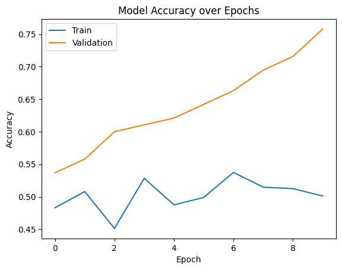

```python
plt.plot(cnn_model_4_train.history['accuracy'])
plt.plot(cnn_model_4_train.history['val_accuracy'])
plt.title('Model Accuracy over Epochs')
plt.ylabel('Accuracy')
plt.xlabel('Epoch')
plt.legend(['Train', 'Validation'], loc='upper left')
plt.show()
```

Observations:

1. In above model, we can see the training data fluctuates heavily
2. Validation data performance continues to rise and reaching max with more epochs

```
14/14 ━━━━━━━━━━━━━━━━━━━━ 2s 81ms/step
3/3 ━━━━━━━━━━━━━━━━━━━━ 1s 366ms/step
Training performance:
              precision    recall  f1-score   support

           0       0.66      0.97      0.79       224
           1       0.94      0.49      0.65       217

    accuracy                           0.73       441
   macro avg       0.80      0.73      0.72       441
weighted avg       0.80      0.73      0.72       441


Validation performance:
              precision    recall  f1-score   support

           0       0.69      0.96      0.80        48
           1       0.93      0.55      0.69        47

    accuracy                           0.76        95
   macro avg       0.81      0.76      0.75        95
weighted avg       0.81      0.76      0.75        95


Validation Confusion Matrix:
3/3 ━━━━━━━━━━━━━━━━━━━━ 0s 25ms/step
```

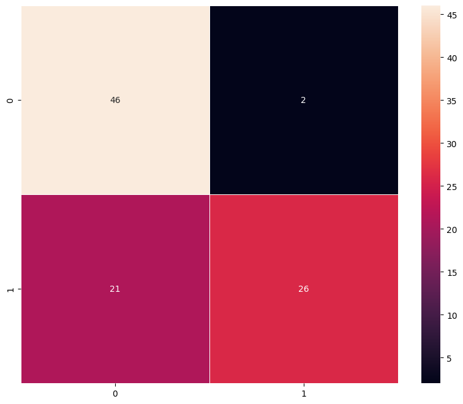

```python
#Evaluate train and validation sets
# Predict on training and validation sets manually
train_preds = cnn_model_4.predict(X_train_vgg)
val_preds = cnn_model_4.predict(X_val_vgg)

# Convert probabilities to binary predictions
train_preds_bin = (train_preds > 0.5).astype(int)
val_preds_bin = (val_preds > 0.5).astype(int)

# Evaluate using  utility functions
print("Training performance:")
print(classification_report(y_train, train_preds_bin))

print("\nValidation performance:")
print(classification_report(y_val, val_preds_bin))

print("\nValidation Confusion Matrix:")
plot_confusion_matrix(cnn_model_4, X_val_vgg, y_val)
```

Observations:

1. False negatives are 21 - Model predicted that no helmet even when people are helmet wearers.
2. False positives are 2 - Model predicted there is helmet when there is no helmet, however it's rare and low count.
3. False negatives in this model - may represent safe in workplace compliance context for safety

```python
#Class distributions
print("Train:", np.bincount(y_train))
print("Val:", np.bincount(y_val))
print("Test:", np.bincount(y_test))
```

```
Train: [224 217]
Val: [48 47]
Test: [48 47]
```

```python
#Vizualizing the predictions

# For index 12
index = 12
plt.figure(figsize=(2, 2))
plt.imshow(X_val[index].reshape(X_val.shape[1], X_val.shape[2]), cmap='gray')  # grayscale view
plt.title(f"Image at index {index}")
plt.show()

# Predict using the RGB-converted version
prediction = cnn_model_4.predict(X_val_vgg[index].reshape(1, X_val.shape[1], X_val.shape[2], 3))
predicted_label = 1 if prediction[0][0] > 0.5 else 0
print('Predicted Label:', predicted_label)
print('Actual Label:', y_val[index])

# For index 33
index = 33
plt.figure(figsize=(2, 2))
plt.imshow(X_val[index].reshape(X_val.shape[1], X_val.shape[2]), cmap='gray')  # grayscale view
plt.title(f"Image at index {index}")
plt.show()

prediction = cnn_model_4.predict(X_val_vgg[index].reshape(1, X_val.shape[1], X_val.shape[2], 3))
predicted_label = 1 if prediction[0][0] > 0.5 else 0
print('Predicted Label:', predicted_label)
print('Actual Label:', y_val[index])
```

```
1/1 ━━━━━━━━━━━━━━━━━━━━ 1s 547ms/step
Predicted Label: 1
Actual Label: 1
```

```
1/1 ━━━━━━━━━━━━━━━━━━━━ 0s 35ms/step
Predicted Label: 0
Actual Label: 0
```

Observations: From the above prediction, we can see that the model predicted both images correctly.

Model Performance Comparison and Final Model **Selection**

```python
cnn_model_4_val_perf = pd.DataFrame({
    "Accuracy": [accuracy_score(y_val, val_preds_bin)],
    "Recall": [recall_score(y_val, val_preds_bin)],
    "Precision": [precision_score(y_val, val_preds_bin)],
    "F1 Score": [f1_score(y_val, val_preds_bin)]
})
```

```python
# Use validation data performance to compare models and make selection

# Create a summary DataFrame
comparison_df = pd.DataFrame({
    "Model": [
        "cnn_model_1 (Basic CNN)",
        "cnn_model_2 (VGG-16 Base)",
        "cnn_model_3 (VGG-16 + FFNN)",
        "cnn_model_4 (VGG-16 + FFNN + Aug)"
    ],
    "Accuracy": [
        cnn_model_1_val_perf["Accuracy"].values[0],
        cnn_model_2_val_perf["Accuracy"].values[0],
        cnn_model_3_val_perf["Accuracy"].values[0],
        cnn_model_4_val_perf["Accuracy"].values[0]
    ],
    "Precision": [
        cnn_model_1_val_perf["Precision"].values[0],
        cnn_model_2_val_perf["Precision"].values[0],
        cnn_model_3_val_perf["Precision"].values[0],
        cnn_model_4_val_perf["Precision"].values[0]
    ],
    "Recall": [
        cnn_model_1_val_perf["Recall"].values[0],
        cnn_model_2_val_perf["Recall"].values[0],
        cnn_model_3_val_perf["Recall"].values[0],
        cnn_model_4_val_perf["Recall"].values[0]
    ],
    "F1 Score": [
        cnn_model_1_val_perf["F1 Score"].values[0],
        cnn_model_2_val_perf["F1 Score"].values[0],
        cnn_model_3_val_perf["F1 Score"].values[0],
        cnn_model_4_val_perf["F1 Score"].values[0]
    ]
})

# Display the comparison
comparison_df.sort_values(by="Accuracy", ascending=False)
```

|  | Model | Accuracy | Precision | Recall | F1 Score |
| --- | --- | --- | --- | --- | --- |
| 2 | cnn_model_3 (VGG-16 + FFNN) | 0.989474 | 0.989689 | 0.989474 | 0.989471 |
| 0 | cnn_model_1 (Basic CNN) | 0.978947 | 0.978947 | 0.978947 | 0.978947 |
| 1 | cnn_model_2 (VGG-16 Base) | 0.978947 | 0.979807 | 0.978947 | 0.978943 |
| 3 | cnn_model_4 (VGG-16 + FFNN + Aug) | 0.757895 | 0.928571 | 0.553191 | 0.693333 |

Observations:

1. From above comparision of models, we can see cnn_model_3 with FFNN is giving high accuracy and recall score.
2. Selecting cnn_model_3 as final model to move forward.

```python
#Test performance
# Confirm test data shape for VGG-16
print(X_test_vgg.shape)
```

```
(95, 200, 200, 3)
```

```
Final Model (cnn_model_3) - Test Set Performance
3/3 ━━━━━━━━━━━━━━━━━━━━ 0s 25ms/step
```

|  | Accuracy | Recall | Precision | F1 Score |
| --- | --- | --- | --- | --- |
| 0 | 1.0 | 1.0 | 1.0 | 1.0 |

```
3/3 ━━━━━━━━━━━━━━━━━━━━ 0s 25ms/step
```

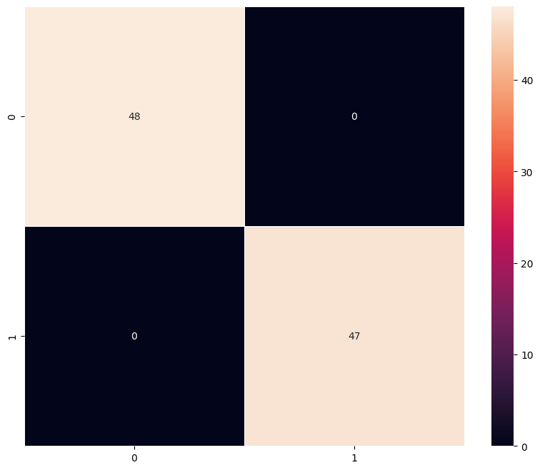

```python
#Evaluate test performance

print("Final Model (cnn_model_3) - Test Set Performance")
cnn_model_3_test_perf = model_performance_classification(cnn_model_3, X_test_vgg, y_test)
display(cnn_model_3_test_perf)

plot_confusion_matrix(cnn_model_3, X_test_vgg, y_test)
```

Observations

1. From the above confusion matrix, we can see the model predicted both classes perfectly for those images with a helmet and without helmet

**Actionable Insights & Recommendations**

Insights:

Business Recommendations:

1. The model is ready for limited deployment and pilot testing. With 100% test set performance. The model is suitable for deployment in controlled environments (e.g., construction sites with mounted cameras). Begin pilot deployments to test real-world generalization and edge cases.
2. Integrate the model into an edge or cloud-based monitoring solution that triggers alerts when workers are detected without helmets, improving real-time safety compliance.
3. Invest in additional labeled data to improve robustness. Even though current performance is excellent, expanding the dataset with more diverse examples (e.g., blurry images, occlusions, different lighting) would further strengthen generalization before full production deployment.
4. Evaluate model bias and failure cases in real-world usage Monitor false positives and false negatives carefully once deployed.